# 1. Processing Data: MR4050

## QC & Filtering of Genes

```r
## calculate qc metrics per gene across all the cells of the same sample
gnqc.list <- do_gene_qc(sce.filt, return_df = TRUE)
gn.qc <- gnqc.list$gene_qc

png(paste0(samplename,"_qc_genes.png"), width=1000, height = 750)
p1 <- ggplot(data = data.frame(gn.qc), aes(x = subsets_WT.MR4050_mean,
  y = subsets_WT.MR4050_detected)) +
  geom_point(shape=1, size=.5) +
  ggtitle(paste("WT", samplename)) +
  scale_x_log10() + scale_y_log10() +
  ylab("% cells with non-zero expression") + xlab("mean counts")
p1 <- p1 +
  geom_point(data = subset(data.frame(gn.qc), Gene %in% gnqc.list$hk_genes),
    color = "red",shape = 22, size = 4)

p2 <- ggplot(data = data.frame(gn.qc), aes(x = subsets_MUT.MR4050_mean,
  y = subsets_MUT.MR4050_detected)) + geom_point(shape=1, size=.5) +
  ggtitle(paste("MUT", samplename)) +
  scale_x_log10() + scale_y_log10() +
  ylab("% cells with non-zero expression") + xlab("mean counts")
p2 <- p2 +
  geom_point(data = subset(data.frame(gn.qc), Gene %in% gnqc.list$hk_genes),
    color = "red",shape = 22, size = 4)

p3 <- ggplot(data = data.frame(gn.qc),
  aes(x = subsets_MUT.MR4050_detected, y = subsets_WT.MR4050_detected)) +
  geom_point(shape=1, size=.5, alpha =.5) +
  scale_x_log10() + scale_y_log10()
p3 <- p3 +
  geom_point(data = subset(data.frame(gn.qc), Gene %in% gnqc.list$hk_genes),
    color = "red",shape = 22, size = 4)
pw <- (p1 | p2) / p3
pw + plot_annotation(title = 'QC of the genes' ,
    subtitle = paste("Sample", samplename))
dev.off()

png(paste0(samplename, "_qc_highestExpressedGenes.png"),
    width= 550, height = 500)
scater::plotHighestExprs(sce.filt)
dev.off()
```

Dropout rate assessment:

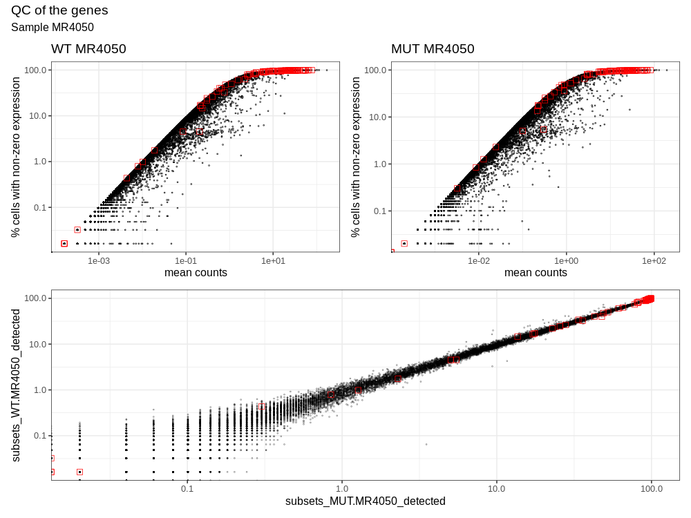

Highest expressed genes:

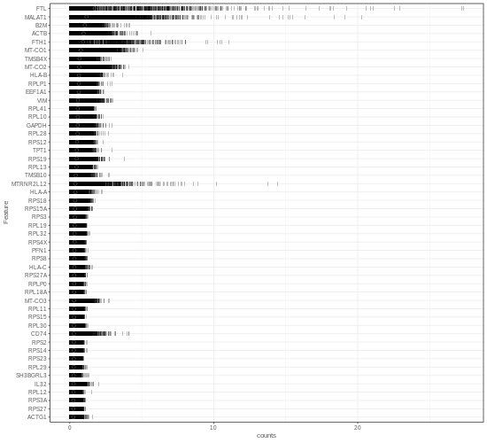

```r
keep_genes <-  do_gene_qc(sce.filt, min.cells = 5, return_df = FALSE)
sce.filt <- sce.filt[keep_genes,]

dim(sce.filt)
# > dim(sce.filt)
#[1]  22055 11157
gene_filt$low_qual_genes <- nrow(sce.filt)

!##saveRDS(sce.filt, file = paste0("sce_", samplename,"_filtered.rds"))
```

## Normalization and Dimensionality Reductions

Following filtering, we’re going to normalize, adjusting for batch effect (=Sample) and performing dimensionality reduction.

```r
library(scran)
library(batchelor)
library(scater)

## size factor --------------------------------------
#message("calculating the size factors")
qckclst <- quickCluster(sce.filt, method = "igraph",
  min.mean = 0.1)
sce.filt <- computeSumFactors(sce.filt, min.mean=0.1, cluster = qckclst)
sce.filt <- scater::logNormCounts(sce.filt)
##!saveRDS(sce.filt, file = paste0("sce_", samplename,"_filtered.rds"))

## variance modelling -------------------------------
dec.filt <- modelGeneVar(sce.filt, block=sce.filt$Sample)
chosen.hvgs <- dec.filt$bio > 0
table(chosen.hvgs)
#chosen.hvgs
#FALSE  TRUE
#13655  8400

#--- merging ---#
set.seed(01001001)
sce.merged <- correctExperiments(sce.filt,
    batch=sce.filt$Sample,
    subset.row=chosen.hvgs)

sce.merged
# class: SingleCellExperiment
# dim: 8400 11157
# metadata(2): merge.info pca.info
# assays(3): reconstructed counts logcounts
# rownames(8400): AL627309.5 LINC01409 ... BX004987.1 MAFIP
# rowData names(4): rotation ensembl_id gene_symbol chr
# colnames(11157): MUT.MR4050_1 MUT.MR4050_2 ... WT.MR4050_7677
#   WT.MR4050_7679
# colData names(21): batch Barcode ... G2Mscore sizeFactor
# reducedDimNames(1): corrected
# altExpNames(0):

##! saveRDS(sce.merged, file = paste0("sce_", samplename, "_batchCorrected.rds"))
```

## Remove cells without clonotype information

```r
## REMOVING CELLS WITHOUT CLONOTYPE----------------------------
sce.filt <- sce.filt[,which(!is.na(sce.filt$cdr3s_aa))]
dim(sce.filt)
# [1] 22055  9066
cell_filt$clonotype <- ncol(sce.filt)

## frequencies of chains, i.e. counting number of TRA/TRB entries within cdr3s_aa column
sce.filt <- add_chain_counts(sce.filt)
## frequency of clonotypes, i.e. counting individual cdr3s_aa entries
sce.filt$freq_per_Sample <- add_frequencies(sce.filt, mode = "per.sample")
sce.filt$freq_across_all <- add_frequencies(sce.filt, mode = "all")

## REMOVING PUTATIVE DOUBLETS --------------------------------
png(paste0(samplename, "_relationship_TRB_features.png"), width = 850)
cd <- colData(sce.filt)
p1 <- ggplot(as.data.frame(cd), aes(x = numTRA,
  y = log10_total_features, color = subsets_mitochondrial_percent)) +
  ggbeeswarm::geom_quasirandom(size = 1, alpha = .5, shape = 1) +
  theme(legend.position = "bottom") +
  scale_colour_viridis_c()

p2 <- ggplot(as.data.frame(cd), aes(x = numTRB,
  y = log10_total_features, color = subsets_mitochondrial_percent)) +
  ggbeeswarm::geom_quasirandom(size = 1, alpha = .5, shape = 1) +
 # ggtitle(" 'Cells' with more than 1 TRB tend to have increased numbers of counts") +
  theme(legend.position = "bottom") +
  scale_colour_viridis_c()

pw <- p1 + p2
pw + plot_annotation(
  title = 'Are multipe TRA/TRB per cell indicative of technical doublets?',
  subtitle = paste("Sample", samplename))
dev.off()

## after looking at these plots, I'm fairly certain that removing cells with more
## than 2 TRB is benefitial to avoid doublets -- there is a clear shift
## towards increased numbers of features for those cells
sce.filt <- sce.filt[, sce.filt$numTRB < 2 & sce.filt$numTRA < 2]
## remove all-newly-only-zero-genes
keep <- rowSums(as.matrix(counts(sce.filt))) > 0
sce.filt <- sce.filt[keep, ]
cell_filt$clonotype_doubs <- ncol(sce.filt)
gene_filt$clonotype_doubs <- nrow(sce.filt)

dim(sce.filt)
#[1] 21659  7379

keep <- do_gene_qc(sce.filt, min.cells = 5, return_df = FALSE)
sce.filt <- sce.filt[keep, ]
dim(sce.filt)
#[1]  20363  7379
gene_filt$clonotype_doubs_min5 <- nrow(sce.filt)
```

## Clustering

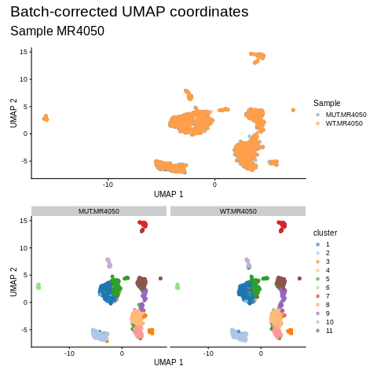

```r
## focus on genes that are actually still part of the filtered
## data set
## note that sce.merged contains all good qual. cells event
## those for which we don't have clonotype information (the
## scRNA-seq info is still valuable!)
kp <- rownames(sce.merged) %in% rownames(sce.filt)
sce.merged <- sce.merged[kp, colnames(sce.filt)]
##  clustering using the batch-corrected values ---------------
g <- buildSNNGraph(sce.merged, use.dimred="corrected")
clusters <- igraph::cluster_louvain(g)
sce.merged$cluster <- factor(clusters$membership)

#--- dimensionality-reduction ---#
sce.merged <- runTSNE(sce.merged, dimred="corrected", external_neighbors=TRUE)
sce.merged <- runUMAP(sce.merged, dimred="corrected", external_neighbors=TRUE)

png(paste0(samplename,"_umap_samples.png"))
p1 <- plotReducedDim(sce.merged, dimred="UMAP", colour_by="Sample") +
    scale_fill_manual(values = c("dodgerblue1","limegreen"))
p2 <- plotReducedDim(sce.merged, dimred="UMAP", colour_by="cluster",
   other_fields = "Sample") +
  facet_grid(~Sample)
pw <- p1 / p2
pw + plot_annotation(title = "Batch-corrected UMAP coordinates", subtitle = paste("Sample", samplename))
dev.off()

##!saveRDS(sce.merged, file = paste0("sce_", samplename, "_batchCorrected.rds"))

## add the red.dim coordinates to the original data set
reducedDims(sce.filt) <- reducedDims(sce.merged)
sce.filt$cluster <- sce.merged$cluster

##! saveRDS(sce.filt, file = paste0("sce_", samplename, "_clonotypefiltered.rds"))
```

# Results

[output not shown]

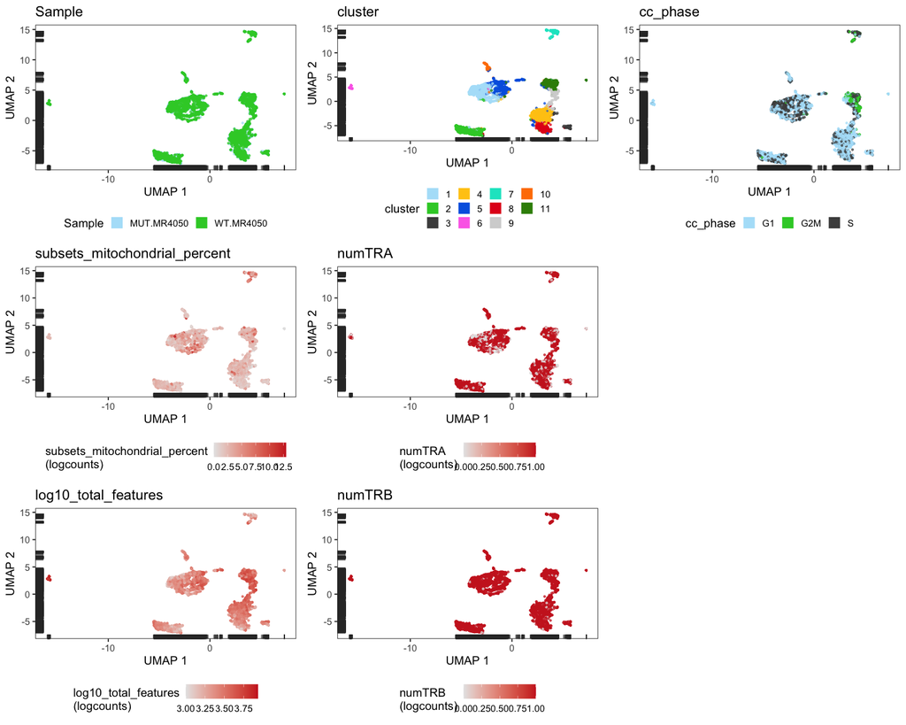

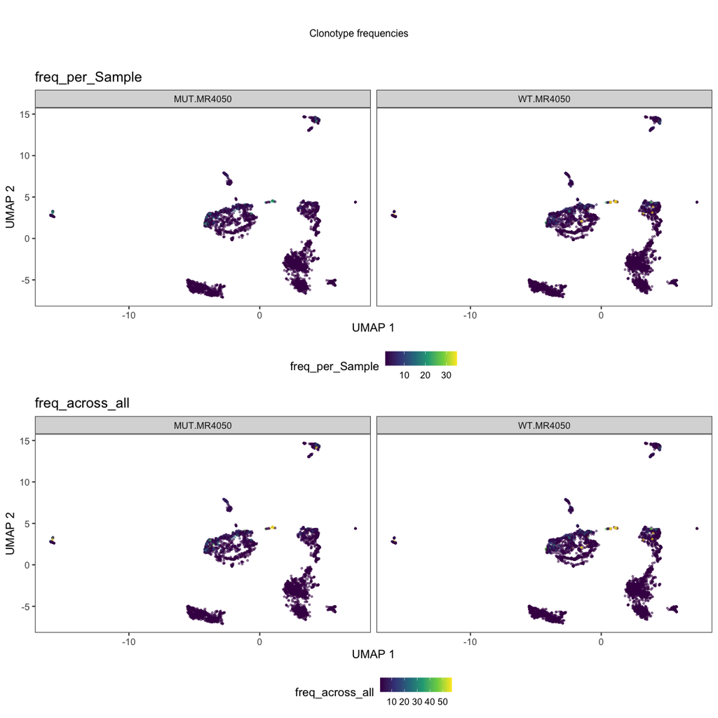

What is the clonotype that is dominant in the cells of the mid-right cluster?

```r
coi <- reducedDim(sce.filt, "UMAP") %>% as.data.frame
coi <- subset(coi, V1 > 0 & V1 < 2 & V2 < 5 & V2 > 4) %>% rownames

## extract the cells
sce.coi <- sce.filt[, coi]
## assess the clonotypes
cd.coi <- as.data.frame(colData(sce.coi)) %>% as.data.table(., keep.rownames = TRUE)
setorder(cd.coi, -freq_per_Sample)
setnames(cd.coi, "rn", "cell")
cd.coi <- cd.coi[, -c("cdr3s_nt","raw_clonotype_id", "Barcode", "subsets_mitochondrial_detected","G1score","G2Mscore"),with=FALSE]
```

The clonotypes that are frequent in that select population are:

```r
tmp <- cd.coi[, .N, cdr3s_aa] %>% .[N>1]
my_table(tmp)
```

| cdr3s_aa | N |
| --- | --- |
| TRB:CASSADSSNTGELFF;TRA:CAVRDPLSNFGNEKLTF | 33 |
| TRB:CASRDRDRVNTEAFF;TRA:CVVNSGASSASKIIF | 3 |
| TRB:CASRVTGASNYGYTF;TRA:CAETRGAGNMLTF | 2 |
| TRB:CASSQDPPRANTGELFF;TRA:CALSEAWDNYGQNFVF | 2 |
| TRB:CASTRQGDRDEQYF;TRA:CAASGGYQKVTF | 2 |

## Monocytes

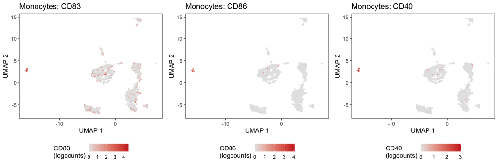

## NK cells, DCs, B cells

[output not shown]

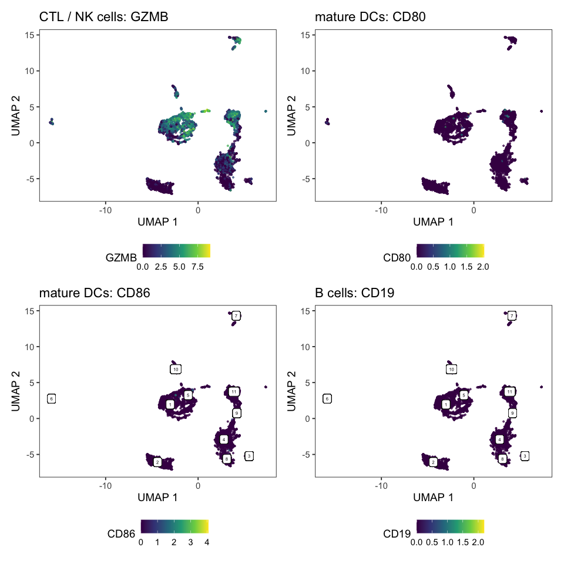

## T cells

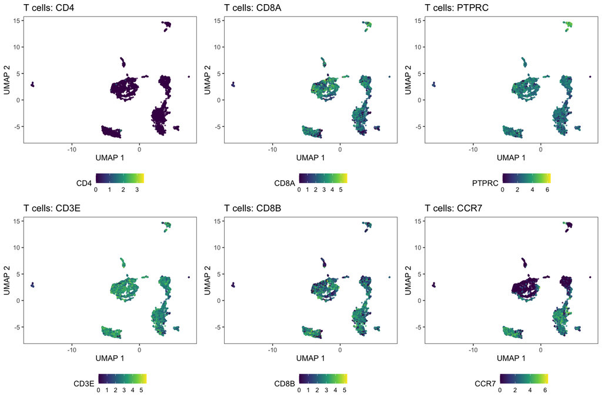

## Markers of activation

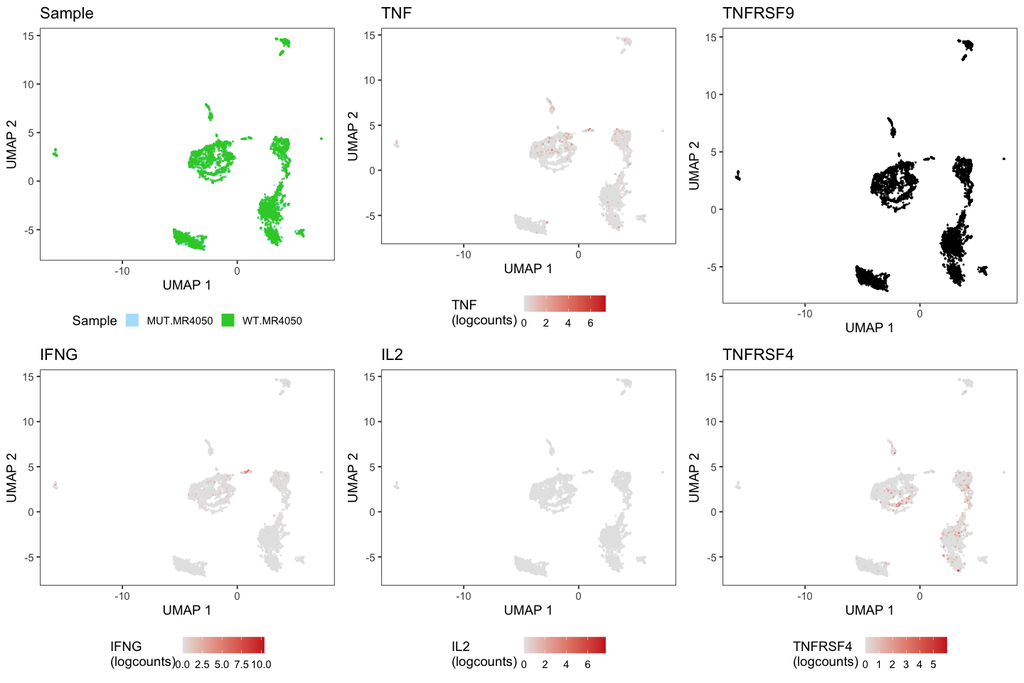

[output not shown]

# Identify shared clonotypes

= clonotypes that are present in both conditions, i.e. MUT and WT.

Get a data.table with unique clonotypes per sample:

```r
## clonotype frequencies
clono_freq <- colData(sce.filt)[, c("Sample" ,"cdr3s_aa")] %>%
  as.data.frame %>% data.table(., keep.rownames = TRUE) %>%
  .[!is.na(cdr3s_aa), .N, c("cdr3s_aa","Sample")]
setorder(clono_freq, N)
```

```
> clono_freq
                                       cdr3s_aa     Sample  N
   1:  TRB:CASSPDRSNYGYTF;TRA:CAVRDIEASGGSYIPTF MUT.MR4050  1
   2:  TRB:CASSNKLTGGLNEQFF;TRA:CAVQDRGSTLGRLYF MUT.MR4050  1
   3:                        TRB:CASSLGVRYNEQFF MUT.MR4050  1
   4:     TRB:CASSFPSGGADTQYF;TRA:CAVPNTGGFKTIF MUT.MR4050  1
   5:      TRB:CASRWGMGGYTF;TRA:CVVTGLSGGYNKLIF MUT.MR4050  1
  ---
6232:   TRB:CASRDRDRVNTEAFF;TRA:CVVNSGASSASKIIF MUT.MR4050 20
6233: TRB:CASSADSSNTGELFF;TRA:CAVRDPLSNFGNEKLTF MUT.MR4050 22
6234:                       TRB:CASSQGGSFTDTQYF MUT.MR4050 23
6235:   TRB:CASRDRDRVNTEAFF;TRA:CVVNSGASSASKIIF  WT.MR4050 24
6236: TRB:CASSADSSNTGELFF;TRA:CAVRDPLSNFGNEKLTF  WT.MR4050 35
```

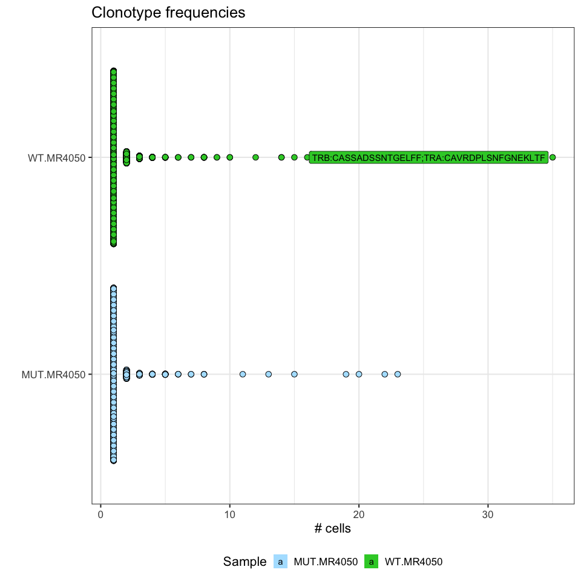

```r
ggplot(clono_freq, aes(x = Sample, y = N, key = cdr3s_aa, fill = Sample)) +
  ggbeeswarm::geom_quasirandom(size = 3, shape = 21) +
  ggrepel::geom_label_repel(data = clono_freq[N>30], aes(label = cdr3s_aa), box.padding = 1) +
  scale_fill_manual(values = c("lightskyblue1","limegreen")) +
  coord_flip() + ylab("# cells") + xlab("") +
  ggtitle("Clonotype frequencies") +
  theme(legend.position = "bottom")
```

As we saw in one of the UMAPs above, there seems to be an association of specific TCR sequences with individual clusters.

```r
ct_per_clust <- colData(sce.filt)[, c("cluster", "cdr3s_aa")]%>% as.data.table
ct_per_clust[, TRB := gsub(".*;(TRB)", "\\1", cdr3s_aa)]
ct_per_clust$cdr3s_aa <- NULL
ct_per_clust <- ct_per_clust[, .N, by = c("cluster","TRB")]

tmp <- copy(clono_freq)
tmp[ ,TRB := gsub(".*;(TRB)", "\\1", cdr3s_aa)]
tmp$cdr3s_aa <- NULL
tmp$Sample <- NULL
tmp <- unique(tmp)
setnames(tmp, "N", "freq_in_sample")

ct_per_clust <- tmp[ct_per_clust, on = "TRB"]
```

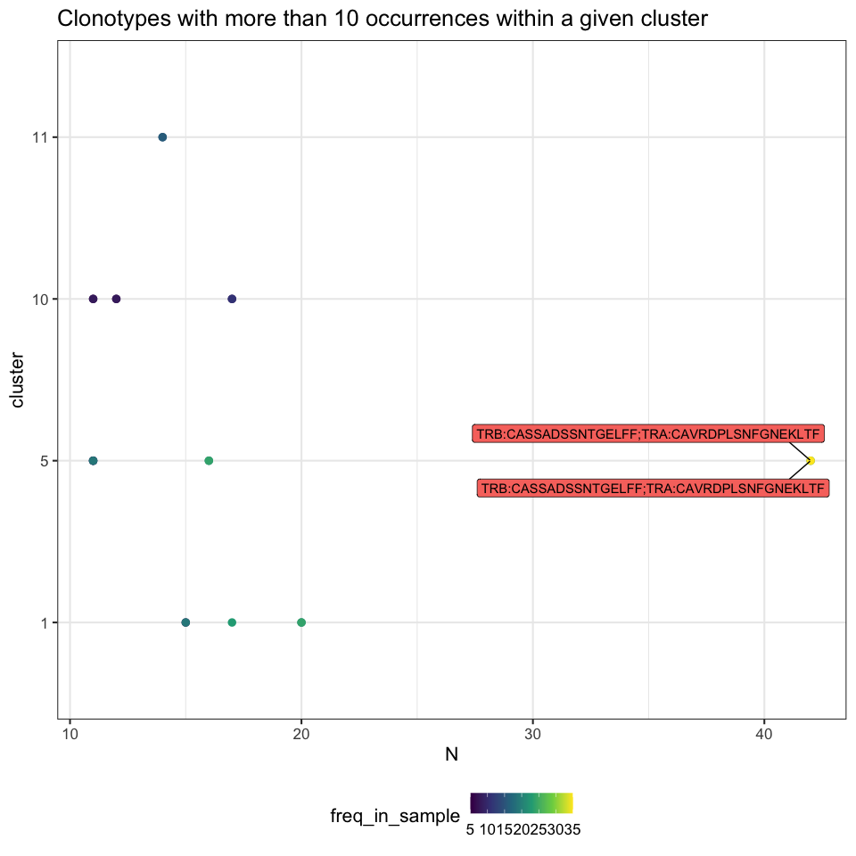

## Identify clonotypes that are **present in both sample types**:

```r
ct <- dcast(clono_freq, cdr3s_aa ~ Sample, value.var = "N") %>%
  .[!is.na(MUT.MR4050) & !is.na(WT.MR4050)]
```

There are 253 clonotypes that are found in both MUT and WT samples.

```r
## formatting the TRA/TRB notations
## will only work if there's just one TRA
ct[, TRA := gsub("TRB:[A-Z]+;.*", "", cdr3s_aa)] ## for MR4050, the order of TRB and TRA was different than for th other samples!
ct[, TRA := ifelse(TRA == "", NA, TRA)]
ct[, TRB := gsub("(TRB:[A-Z]+).*", "\\1", cdr3s_aa)]
ct[, TRB := ifelse(grepl("^TRA", TRB), NA, TRB)] # if only TRB was present, I need to fill in the NA

setorder(ct, -MUT.MR4050, -WT.MR4050 )
```

```
>ct
                                      cdr3s_aa MUT.MR4050 WT.MR4050               TRA                    TRB
  1: TRB:CASSADSSNTGELFF;TRA:CAVRDPLSNFGNEKLTF         22        35              <NA>    TRB:CASSADSSNTGELFF
  2:   TRB:CASRDRDRVNTEAFF;TRA:CVVNSGASSASKIIF         20        24              <NA>    TRB:CASRDRDRVNTEAFF
  3:   TRB:CASSSQLTGLNTGELFF;TRA:CAVSSNNNARLMF         19         7              <NA>  TRB:CASSSQLTGLNTGELFF
  4:     TRB:CAWMGEGGRVDEQYF;TRA:CAGATNRDDKIIF         15        16              <NA>    TRB:CAWMGEGGRVDEQYF
  5:         TRB:CASSYGQGIVEGNTEAFF;TRA:CARISF         13        14              <NA> TRB:CASSYGQGIVEGNTEAFF
 ---
249:       TRB:CSASLGEGADTQYF;TRA:CAVTDSNYQLIW          1         1              <NA>     TRB:CSASLGEGADTQYF
250:   TRB:CSATRRQGPRWYEQYF;TRA:CLVGDMNRDDKIIF          1         1              <NA>   TRB:CSATRRQGPRWYEQYF
251:                         TRB:CSVEDYSRGEAFF          1         1 TRB:CSVEDYSRGEAFF      TRB:CSVEDYSRGEAFF
252:      TRB:CSVLDPGAGYEQYF;TRA:CAVLIYNFNKFYF          1         1              <NA>     TRB:CSVLDPGAGYEQYF
253:          TRB:CSVRGNEQFF;TRA:CAASIEGAQKLVF          1         1              <NA>         TRB:CSVRGNEQFF
```

## Dimensionality reduction on the shared clonotypes only

UMAP of **shared clonotypes**

```r
sce.shared <- sce.filt[, sce.filt$cdr3s_aa %in% ct$cdr3s_aa]
#dim(sce.shared)
#[1] 20363  1221
```

There are 1221 cells in the SCE object with clonotypes that are present in both samples.

```r
set.seed(123)
sce.shared <- scater::runUMAP(sce.shared,
  exprs_values = "logcounts",
  dimred = "corrected")
```

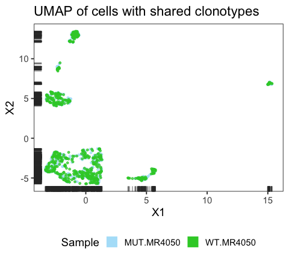

Is there evidence for doublets again?

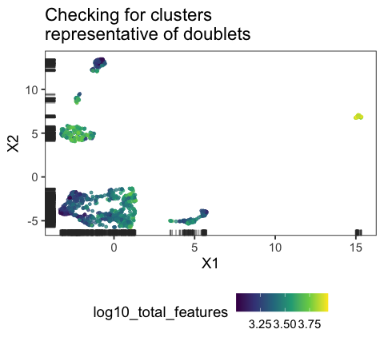

Yes, the cluster in the top right corner (cluster 6).

## Removal of suspected doublets

Let’s remove them.

```r
outs <- colnames(sce.filt[, as.character(sce.filt$cluster) == "6"])
sce.shared$umap_group <- ifelse(rownames(colData(sce.shared)) %in% outs, "doublets", "tcells")
table(sce.shared$umap_group)
```

```
#>
#> doublets   tcells
#>       39     1182
```

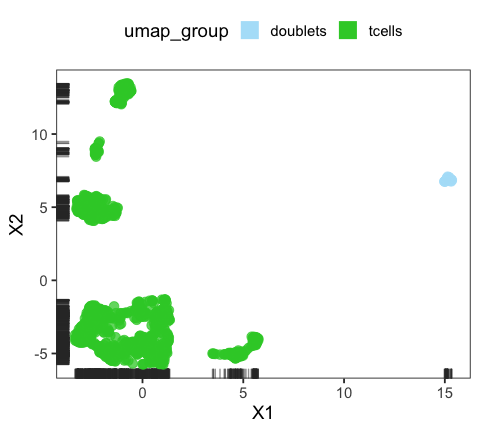

```r
## remove doublets from the SCE
sce.shared <- sce.shared[, sce.shared$umap_group != "doublets"]
dim(sce.shared)
# [1] 20363  1182
set.seed(123)
sce.shared <- scater::runUMAP(sce.shared, exprs_values = "logcounts",
  dimred = "corrected")
colnames(reducedDim(sce.shared, "UMAP")) <- c("UMAP_1","UMAP_2")
```

[figure not shown]

## Re-calculate the clonotype frequencies after the removal of the doublets

```r
shared_clonotypes <- colData(sce.shared)[, c("Sample" ,"cdr3s_aa")] %>%
    as.data.frame %>% data.table(., keep.rownames = TRUE) %>%
    .[!is.na(cdr3s_aa), .N, c("cdr3s_aa","Sample")] %>%
  dcast(., cdr3s_aa ~ Sample, value.var = "N") %>% .[!is.na(MUT.MR4050) & !is.na(WT.MR4050)]
shared_clonotypes[, TRA := gsub("TRB:[A-Z]+.;", "", cdr3s_aa)]
shared_clonotypes[, TRA := ifelse(TRA == "", NA, TRA)]
shared_clonotypes[, TRB := gsub("(TRB:[A-Z]+).*", "\\1", cdr3s_aa)]
shared_clonotypes[, TRB := ifelse(grepl("^TRA", TRB), NA, TRB)] # if only TRB was present, I need to fill in the NA
setorder(shared_clonotypes, -MUT.MR4050, -WT.MR4050 )

## rm those cells that are no longer shared across conditions
sce.shared <- sce.shared[, sce.shared$cdr3s_aa %in% unique(shared_clonotypes$cdr3s_aa)]
dim(sce.shared)
#[1] 20363  1173
```

## Adding the clonotype IDs

```r
## extract all shared clonotypes
tt.ori <- data.table(cdr3s_aa = unique(shared_clonotypes$cdr3s_aa))

## work on a backup
tt.ori2 <- copy(tt.ori)

## split the individual entries per clonotype -- I tested in a dry run how many
## columns I had to assign for this; 2 is sufficient for this case -- might not always
## be the case:
## strsplit(tt.ori$cdr3s_aa, ";") %>% lapply(., length) %>% unlist %>% table
tt.ori2[, c("T1","T2"):=tstrsplit(cdr3s_aa, ";")]

## count TRA & TRB
tt.ori2[, num_TRA := stringr::str_count(cdr3s_aa, "TRA")]
tt.ori2[, num_TRB := stringr::str_count(cdr3s_aa, "TRB")]

## extract those where we have one or two TRA, but just one TRB
## (we will add the single TRA| single TRB instances later)
tt.good <- tt.ori2[ (num_TRA == 1|num_TRA ==2) & num_TRB == 1,
                    c("cdr3s_aa","T1","T2", "num_TRA","num_TRB"),
                    with=FALSE] %>% unique
setorder(tt.good, T1, T2)
## assign arbitrary ID
maxn <- nrow(tt.good)
tt.good[, id := paste0("C",1:maxn)]

## obtain a skinny list of IDs and original cdr3s_aa entries
## coupled to the individual TRA and TRB
tt.good <- melt(tt.good[, -c("num_TRA","num_TRB"),with=FALSE],
                id.vars = c("id","cdr3s_aa")) %>%
  .[!is.na(value)] %>% .[, -"variable", with = FALSE] %>% unique

## add the cases with only one TRA or only one TRB (would have messed up the
## workflow above otherwise)
tt.quest <- tt.ori2[num_TRA < 1 | num_TRB < 1,
  c("cdr3s_aa","T1","T2", "num_TRA","num_TRB"),with=FALSE] %>% unique

## combine good and questionable CDRs
tt.combi <- merge(tt.good, tt.quest, by.x = "value", by.y = "T1", all = TRUE)
setorder(tt.combi, value)

## the instances from tt.quest without a match in tt.good will have an NA in the ID,
## which will have to be rectified
n_na <- nrow(tt.combi[is.na(id)])
tt.combi[is.na(id), id := paste0("C", (maxn+1):(maxn + n_na))]

## keep the original entries from either tt.good or tt.quest; the result will be
## the longest possible combination, i.e. TRA:CAGINAGGTSYGKLTF will belong to TRA:CAGINAGGTSYGKLTF;TRB:CASSLVPGDAYEQYF
tt.combi <- tt.combi[, cdr3s_consolidated := ifelse(is.na(cdr3s_aa.x), cdr3s_aa.y, cdr3s_aa.x)]

## clean up
tt.combi <- unique(tt.combi[, c("id","cdr3s_aa.x","cdr3s_aa.y", "cdr3s_consolidated"), with=FALSE])
setnames(tt.combi, c("cdr3s_aa.x","cdr3s_aa.y"), c("cdr3s_aa.good", "cdr3s_aa.single"))

## bring back the original CDRs
tt.combi <- merge(tt.ori, tt.combi, by.x = "cdr3s_aa" ,by.y = "cdr3s_aa.good", all.x = TRUE) %>%
  merge(., tt.combi, by.x = "cdr3s_aa", by.y = "cdr3s_aa.single", all.x = TRUE)
tt.combi[, id := ifelse(is.na(id.x), id.y, id.x)]
tt.combi[, cdr3s_consolidated := ifelse(is.na(cdr3s_consolidated.x), cdr3s_consolidated.y, cdr3s_consolidated.x)]
tt.combi <- unique(tt.combi[, c("cdr3s_aa", "id","cdr3s_consolidated"), with=FALSE])

clonotype_ids <- copy(tt.combi)
clonotype_ids$Patient <- "MR4050"
clonotype_ids <- shared_clonotypes[clonotype_ids, on = "cdr3s_aa"]
```

```
> clonotype_ids
                                      cdr3s_aa MUT.MR4050 WT.MR4050                    TRA                  TRB   id
  1:                         TRA:CAVREYTGNQFYF          1         3      TRA:CAVREYTGNQFYF                 <NA> C209
  2: TRB:CAGPTGRSFNEQFF;TRA:CAFMKSGAGGTSYGKLTF          5         5 TRA:CAFMKSGAGGTSYGKLTF   TRB:CAGPTGRSFNEQFF   C1
  3:        TRB:CAGQGSYGYTF;TRA:CGADTGAGSYQLTF          1         1     TRA:CGADTGAGSYQLTF      TRB:CAGQGSYGYTF   C2
  4:  TRB:CAINRGGGVSTDTQYF;TRA:CAFMINTGTASKLTF          1         1    TRA:CAFMINTGTASKLTF TRB:CAINRGGGVSTDTQYF   C3
  5:   TRB:CAISDGGVANGYTF;TRA:CAMREGRPGSARQLTF          1         1   TRA:CAMREGRPGSARQLTF   TRB:CAISDGGVANGYTF   C4
 ---
244:                         TRB:CSVEDYSRGEAFF          1         1      TRB:CSVEDYSRGEAFF    TRB:CSVEDYSRGEAFF C205
245:  TRB:CSVEDYSRGEAFF;TRA:CAYRSANAGGTSYGKLTF          1         3 TRA:CAYRSANAGGTSYGKLTF    TRB:CSVEDYSRGEAFF C205
246:      TRB:CSVLDPGAGYEQYF;TRA:CAVLIYNFNKFYF          1         1      TRA:CAVLIYNFNKFYF   TRB:CSVLDPGAGYEQYF C206
247:     TRB:CSVLFLGEQYF;TRA:CIVRGLRSGAGSYQLTF          2         3  TRA:CIVRGLRSGAGSYQLTF      TRB:CSVLFLGEQYF C207
248:          TRB:CSVRGNEQFF;TRA:CAASIEGAQKLVF          1         1      TRA:CAASIEGAQKLVF       TRB:CSVRGNEQFF C208
                            cdr3s_consolidated Patient
  1:                         TRA:CAVREYTGNQFYF  MR4050
  2: TRB:CAGPTGRSFNEQFF;TRA:CAFMKSGAGGTSYGKLTF  MR4050
  3:        TRB:CAGQGSYGYTF;TRA:CGADTGAGSYQLTF  MR4050
  4:  TRB:CAINRGGGVSTDTQYF;TRA:CAFMINTGTASKLTF  MR4050
  5:   TRB:CAISDGGVANGYTF;TRA:CAMREGRPGSARQLTF  MR4050
 ---
244:  TRB:CSVEDYSRGEAFF;TRA:CAYRSANAGGTSYGKLTF  MR4050
245:  TRB:CSVEDYSRGEAFF;TRA:CAYRSANAGGTSYGKLTF  MR4050
246:      TRB:CSVLDPGAGYEQYF;TRA:CAVLIYNFNKFYF  MR4050
247:     TRB:CSVLFLGEQYF;TRA:CIVRGLRSGAGSYQLTF  MR4050
248:          TRB:CSVRGNEQFF;TRA:CAASIEGAQKLVF  MR4050
```

### Add clonotype ID and consolidated info to the SCE object

```r
## formatting colData
cd.ct <-  data.table(as.data.frame(colData(sce.shared)), keep.rownames = TRUE)
cd.ct <- clonotype_ids[cd.ct, on = "cdr3s_aa"]
cd.ct <-  DataFrame(cd.ct[, -c("rn", "MUT.MR4050","WT.MR4050")], row.names = cd.ct$rn)
colData(sce.shared) <- cd.ct[colnames(sce.shared),]
##!saveRDS(sce.shared, file = "~/Documents/Projects/2018-10_Smita/data/sce_sharedClonotypes_MR4050.RDS")

# add the info to the big data set, too, in case we ever want to go back
cd.all <- data.table(as.data.frame(colData(sce.filt)), keep.rownames = TRUE)
cd.all <- clonotype_ids[cd.all, on = "cdr3s_aa"]
cd.all <-  DataFrame(cd.all[, -c("rn", "MUT.MR4050","WT.MR4050")], row.names = cd.all$rn)
colData(sce.filt) <- cd.all[colnames(sce.filt),]

## determine cells where we have at least 2 instances per condition
testfit <- clonotype_ids[ MUT.MR4050 > 1 & WT.MR4050 > 1]$id %>% unique
## adjust the frequencies of the TRB.TRA
sce.shared$freq_per_Sample <- add_frequencies(sce.shared, count_what = "id", mode = "per.sample")
sce.shared$freq_across_all <- add_frequencies(sce.shared, count_what = "id",mode = "all")
sce.shared$fit_for_test <- ifelse(sce.shared$id %in% testfit, TRUE, FALSE)
```

## Saving

Small files such as clonotype IDs and the numbers of cells and genes that were removed during filtering are stored within the package (`data/`).

```r
## for data stored in the data/ folder of the package
usethis::use_data(cell_filt)
usethis::use_data(gene_filt)

usethis::use_data(shared_clonotypes, overwrite = TRUE)
usethis::use_data(clonotype_ids, overwrite = TRUE)

usethis::use_data(sce.shared)
```

Bigger data sets, such as the `SingleCellExperiment` objects, are stored in the Box. They will be loaded and kept in temporary cache with specific functions. The URLs pointing to the individual components of the `SingleCellExperiment` objects are noted in `.txt` files stored in `inst/extdata/`

This is what the storage file should like like:

```
#>                V1
#> 1         rowData
#> 2         colData
#> 3 assay:logcounts
#> 4        metadata
#> 5    assay:counts
#> 6     reducedDims
#>                                                                       V2     V3
#> 1 https://wcm.box.com/shared/static/a2p8jksx6ym2g65una4btyi2xcsak854.rds MR4050
#> 2 https://wcm.box.com/shared/static/eij5vcz90d7gxy19jx13ft34a3k1szxa.rds MR4050
#> 3 https://wcm.box.com/shared/static/1krbbfrocqxmncl9f3dxgrc4pgnwyg2r.rds MR4050
#> 4 https://wcm.box.com/shared/static/z8zpc5i2130boqkv2qy01ajrhm5sx9v4.rds MR4050
#> 5 https://wcm.box.com/shared/static/ay2hz6s3hkc9a6fee6v771iu7msdakok.rds MR4050
#> 6 https://wcm.box.com/shared/static/dxj7j2h9ixoexq2wv97gpn8wupoug1cy.rds MR4050
```

There are three storage files:

| File name | Content | Function for loading |
| --- | --- | --- |
| `sce_storage_MR4050.txt` | data for reconstituting `sce.filt` | `load_MR4050filt()` |
| `sce_storage_MR4050Merged.txt` | data for `sce.merged`, i.e. batch-corrected dim. rds | `load_MR4050merged()` |
| `sce_storage_MR4050Shared.txt` | data for `sce.shared`, i.e. those cells that have clonotypes that are present in both MUT and WT condition | `load_MR4050shared()` |

```r
sink("sessionInfo_MR4050.txt")
sink()
```